# Fenestrated EVAR in Greater Glasgow & Clyde

Martin Hennessy

30/08/2022

# 1 Timeline of data

- The first fEVAR was performed on 17 December 2009
- Since then 71 have been performed up until 31 August 2022
- However, the fEVAR performed before 25 November 2015 were offered ad hoc and only the remaining 63 are counted as part of the formal fEVAR ‘service’
- The number of infra-renal EVAR and fEVAR per year since the first fEVAR was performed are shown below:

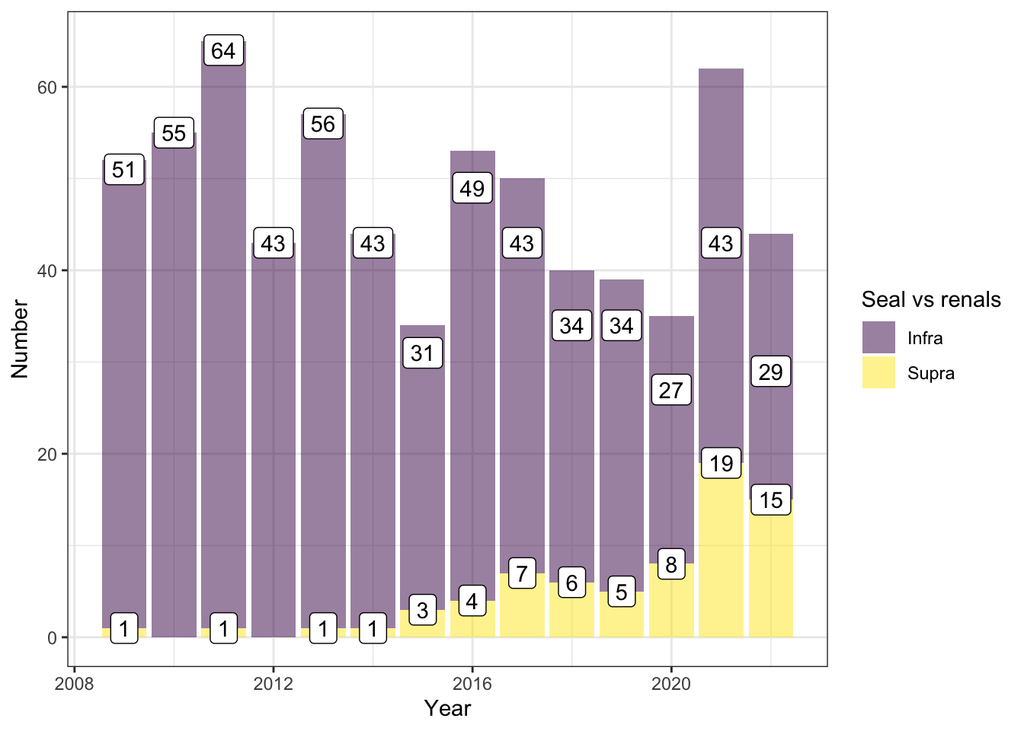

# 2 Patients

## 2.1 Sex

- Patient’s sex is show on the following column chart:

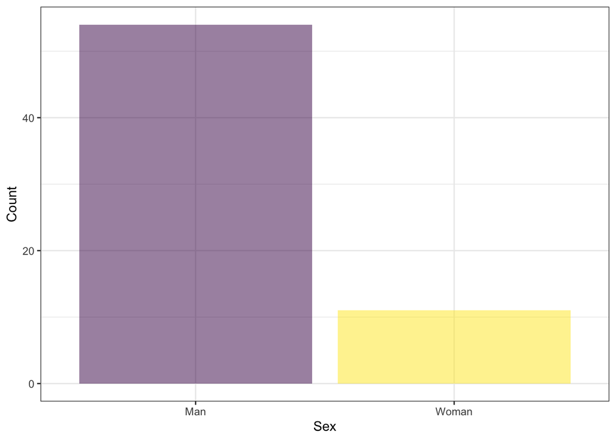

## 2.2 Age

- Patient ages varies from 60 to 85 years old with the distribution shown on the following histogram:

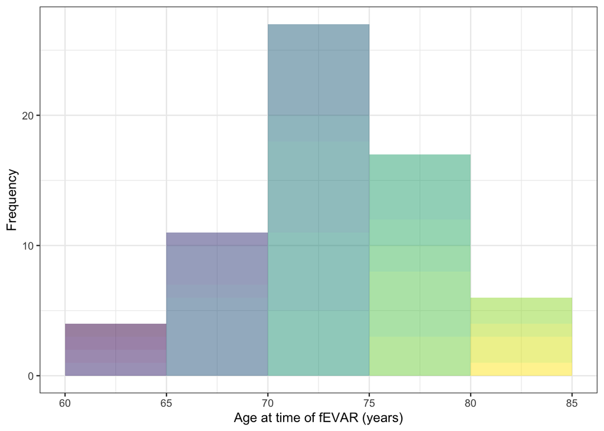

- These data look normally distributed but this can be tested by Shapiro Wilk normality test with the null hypothesis that the age data are normally distributed. *p* = 0.49.
- Data are therefore best summarised with mean and standard deviation:

| Characteristic | Value (years) |
| --- | --- |
| Mean age | 74 |
| Standard deviation | 5 |

## 2.3 Health Board

- Not all fEVAR are for Greater Glasgow & Clyde health board patients.
- Since 2019, Greater Glasgow & Clyde health board has taken over the vascular services of Forth Valley health board.
- The patient’s health board are shown on the following column chart:

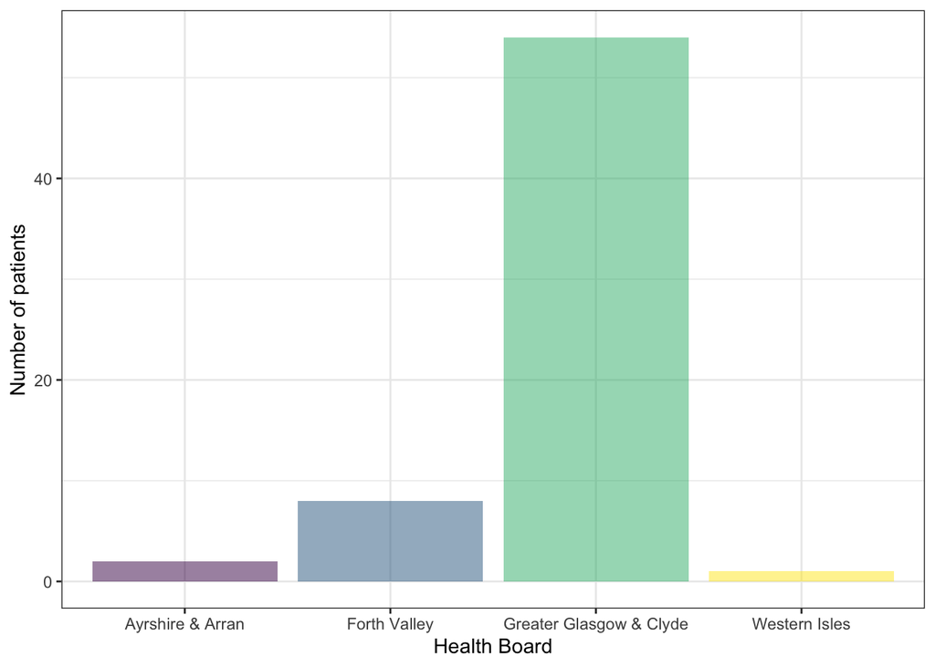

# 3 Aneurysms

## 3.1 Screening

- Excluding women (who are not offered screening) and the fenestrated cuffs placed within existing EVARs, the numbers of screened versus non-screened aneurysms treated by fEVAR are shown below:

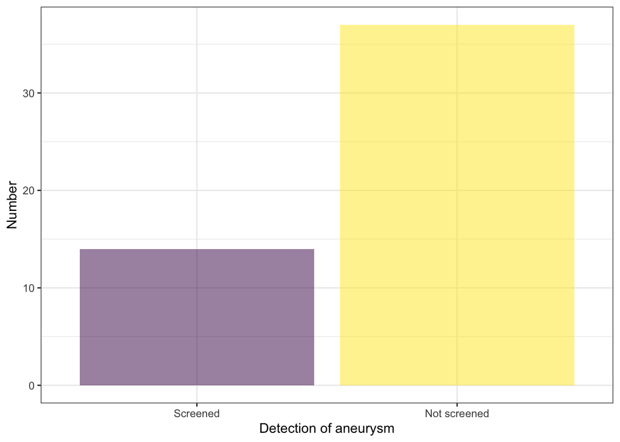

## 3.2 Size

- Treated aneurysm size varies from 40 mm (in a patient with a common iliac artery at treatment threshold and AAA below treatment threshold) to 86 mm, as shown on the following histogram:

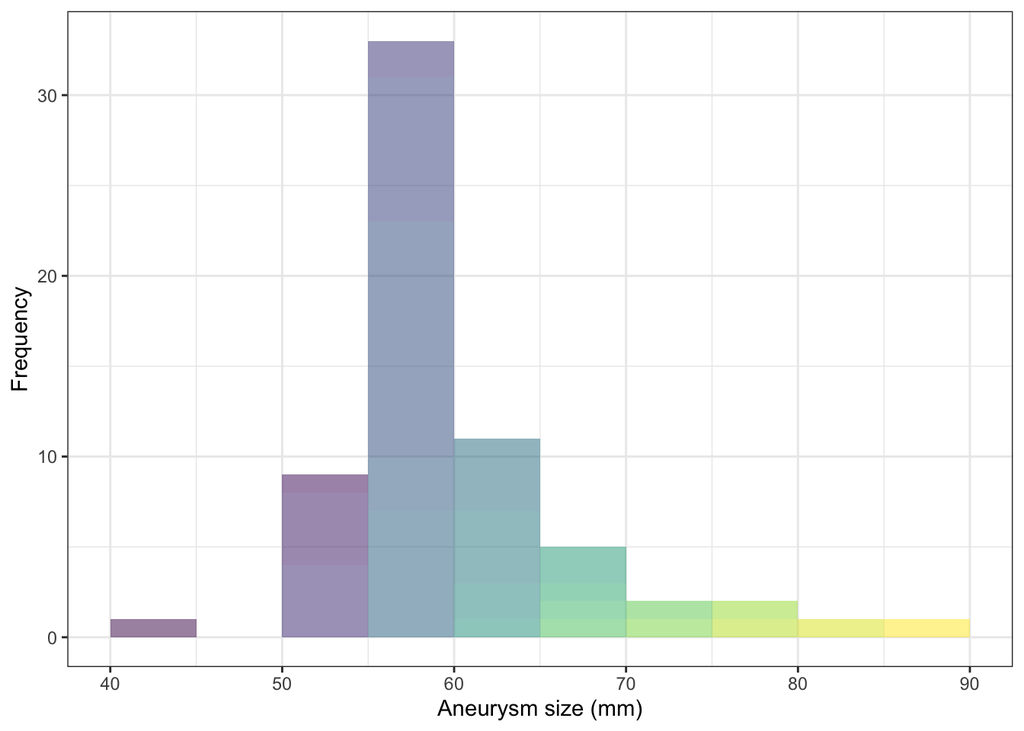

- These data look possibly normally distributed but this can be tested by Shapiro Wilk normality test with the null hypothesis that the age data are normally distributed. *p* = 0 (ie. they are abnormally distributed)
- Data are therefore best summarised with median and interquartile range:

| Characteristic | Value (mm) |
| --- | --- |
| Median size | 58 |
| Interquartile range | 57 - 62 |

# 4 Investigations after aneurysm reaches treatment threshold size

## 4.1 Time to CT

- Time to CT is defined as the time between imaging showing the aneurysm to have reached treatment threshold until the planning CT angiogram.
- In 8 cases, a CT suitable for planning was the investigation which showed the aneurysm to be at threshold and so time to CT was 0 days.
- These cases are therefore excluded from the following.
- Time to CT is shown on the following histogram:

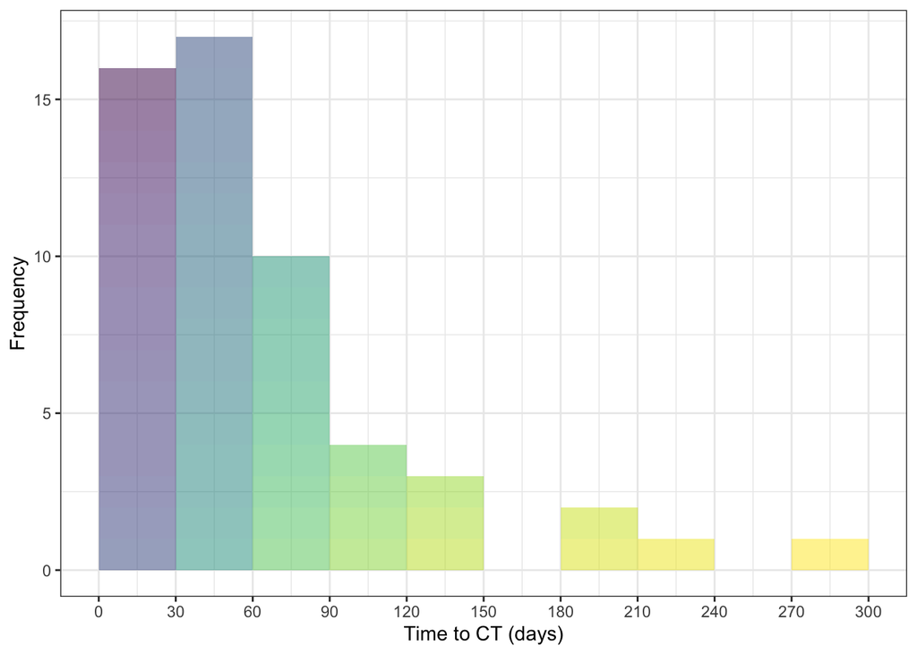

- These look abnormally distributed.
- Comparison of time to CT between screened and non-screened patients can be visualised as a boxplot, given that boxplots display the median and IQR which are the appropriate measures for these data:

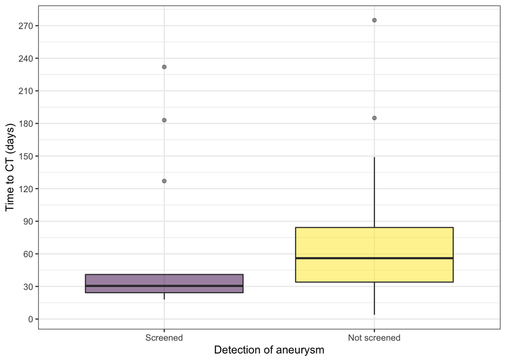

- These look different and this can be tested with a Mann Whitney U test to compare the groups with the alternative hypothesis that screened patients wait less time to have CTA.
- *p* = 0.05 - the alternative hypothesis can be accepted.

## 4.2 Time to ECHO

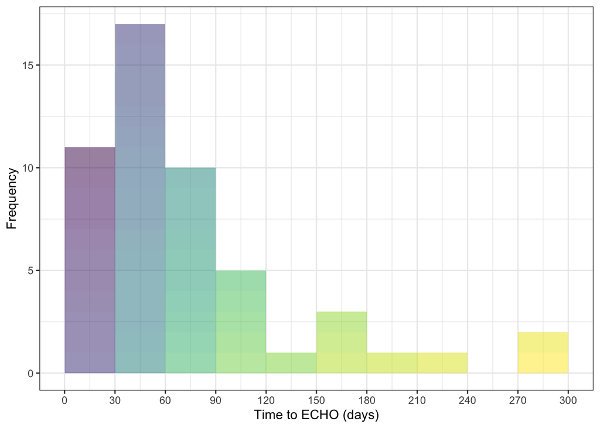

- These look abnormally distributed.
- Comparison of time to ECHO between screened and non-screened patients can be visualised as a boxplot, given that boxplots display the median and IQR which are the appropriate measures for these data:

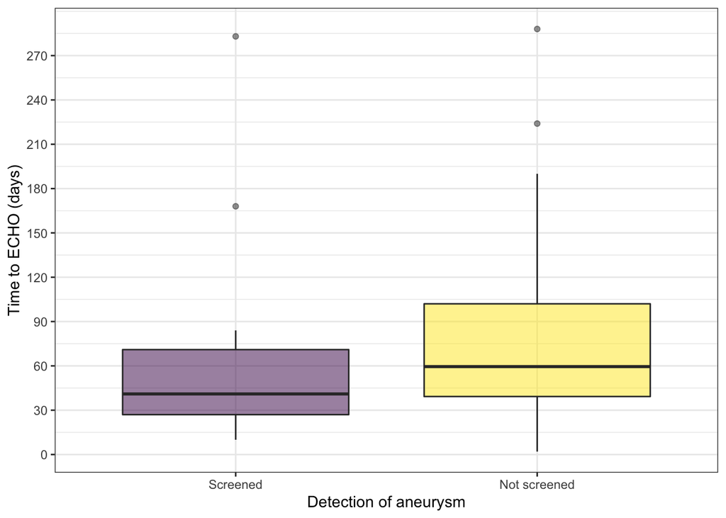

- These look similar and this can be tested with a Mann Whitney U test to compare the groups with the alternative hypothesis that screened patients wait less time to have ECHO.
- *p* = 0.1 - the null hypothesis that there is no difference in time to ECHO cannot be rejected.

## 4.3 Time to PFT

- 8 patients did not have documented pulmonary function tests.
- 6 patients had PFTs prior to their imaging reaching treatment threshold size and did not have it repeated prior to fEVAR.
- That leaves 48 patients who had PFT after reaching treatments threshold.
- The distribution of time to PFT is shown in the following histogram:

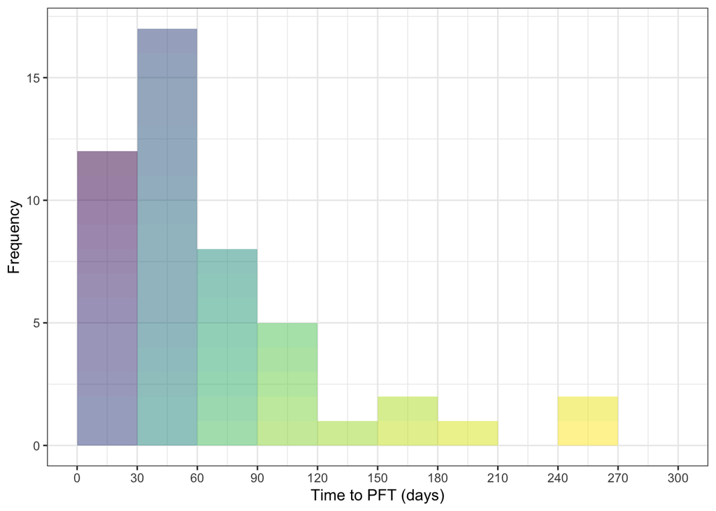

- These look abnormally distributed.
- Comparison of time to PFT between screened and non-screened patients can be visualised as a boxplot, given that boxplots display the median and IQR which are the appropriate measures for these data:

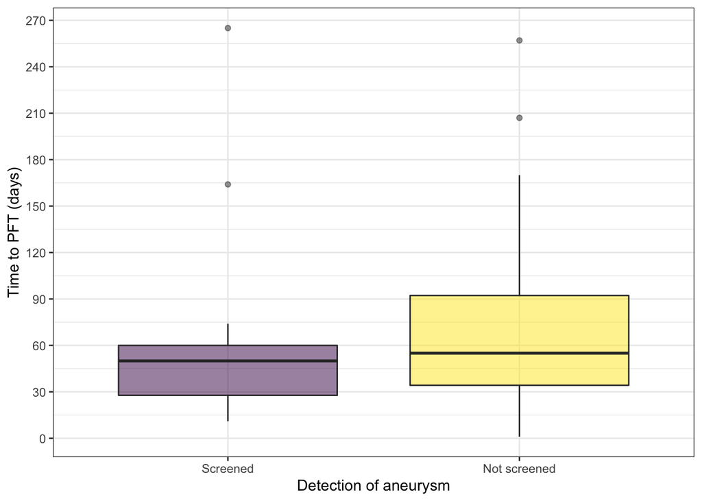

- These look similar and this can be tested with a Mann Whitney U test to compare the groups with the alternative hypothesis that screened patients wait less time to have PFT.
- *p* = 0.2 - the null hypothesis that there is no difference in time to PFT cannot be rejected.

## 4.4 Time to MDT

- 7 patients did not have documented MDT discussion.
- 2 patients had MDT discussion prior to their imaging reaching treatment threshold size and did not have it repeated prior to fEVAR.
- That leaves 53 patients who had MDT after reaching treatments threshold.
- The distribution of time to MDT is shown in the following histogram:

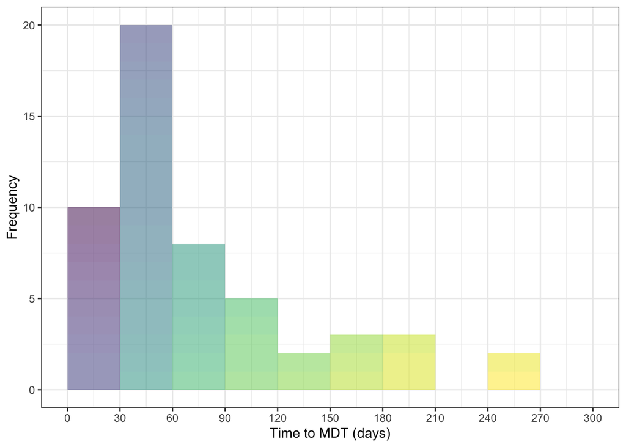

- These look abnormally distributed.
- Comparison of time to MDT between screened and non-screened patients can be visualised as a boxplot, given that boxplots display the median and IQR which are the appropriate measures for these data:

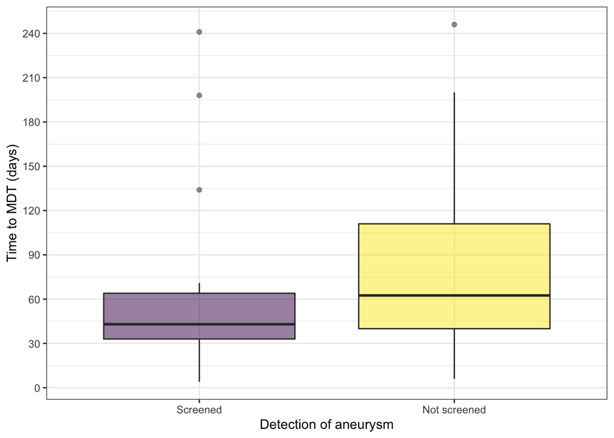

- These look similar and this can be tested with a Mann Whitney U test to compare the groups with the alternative hypothesis that screened patients wait less time to have MDT.
- *p* = 0.09 - the null hypothesis that there is no difference in time to MDT cannot be rejected.

## 4.5 Time to fEVAR

- The distribution of time to fEVAR is shown in the following histogram:

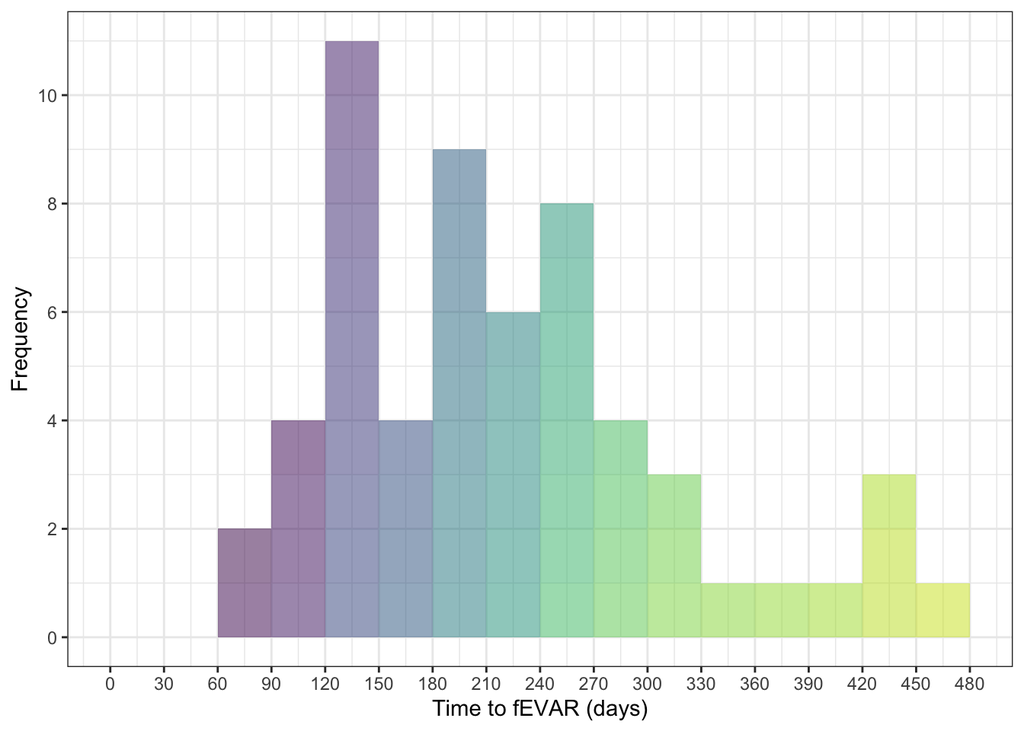

- These look abnormally distributed.
- Median and IQR for time to fEVAR are shown below:

| Characteristic | Value (days) |
| --- | --- |
| Median time | 222 |
| Interquartile range | 147.25 - 277.75 |

- Comparison of time to fEVAR between screened and non-screened patients can be visualised as a boxplot, given that boxplots display the median and IQR which are the appropriate measures for these data:

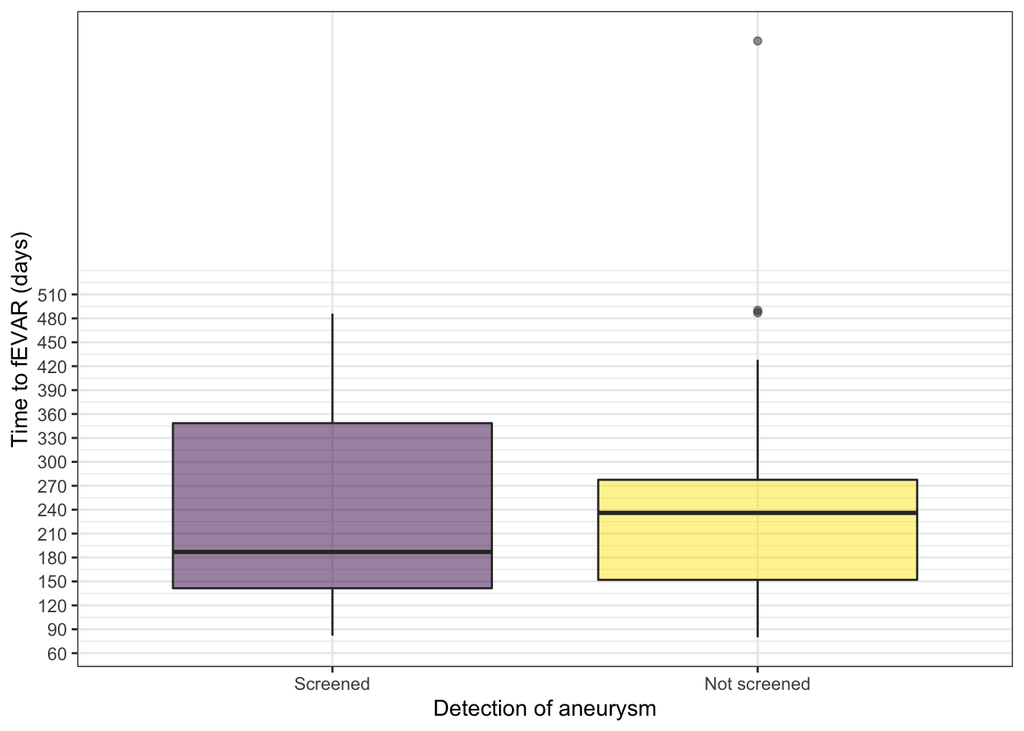

- These look similar and this can be tested with a Mann Whitney U test to compare the groups with the alternative hypothesis that screened patients wait less time to have fEVAR.
- *p* = 0.35 - the null hypothesis that there is no difference in time to fEVAR cannot be rejected.

## 4.6 Comparative timeline

- The different time delays presented above can be shown together in a single boxplot:

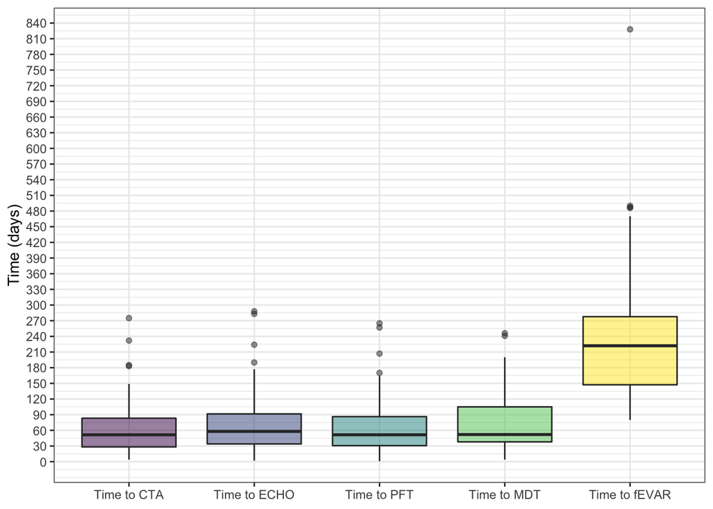

- It is visually apparent that CT imaging, ECHO, PFTs and MDT discussion are parallel investigations with none incurring a particular time penalty.
- There is a subsequent delay to the procedure, some of which can be accounted for by the time taken to manufacture a custom stent-graft.

# 5 Procedural details

## 5.1 Technical

### 5.1.1 Device

- The number of each type of stent-graft used are shown in the following chart:

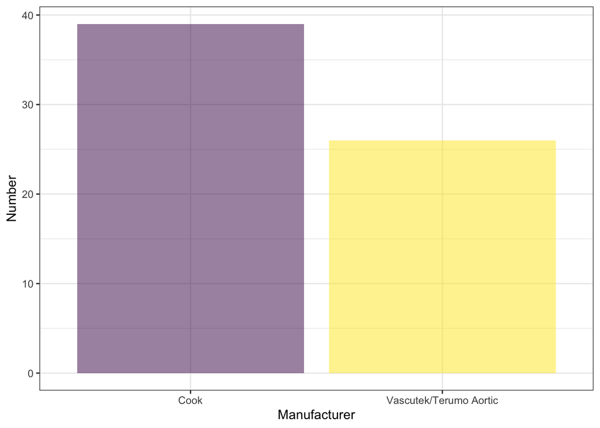

- However this chart hides the fact that the choice of stent-graft has changed over time, as shown below:

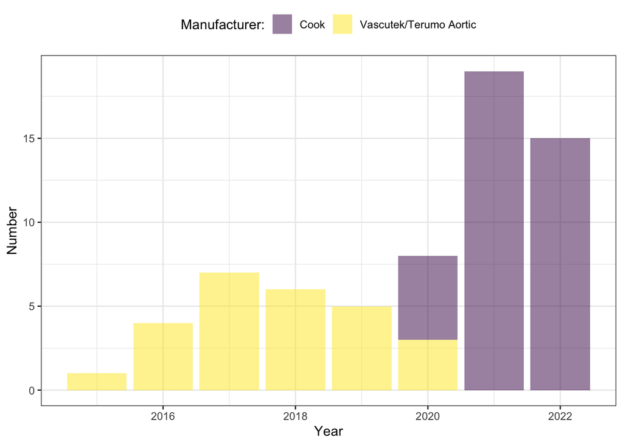

### 5.1.2 fEVAR type

- The number of each type of fEVAR are shown in the folling chart:

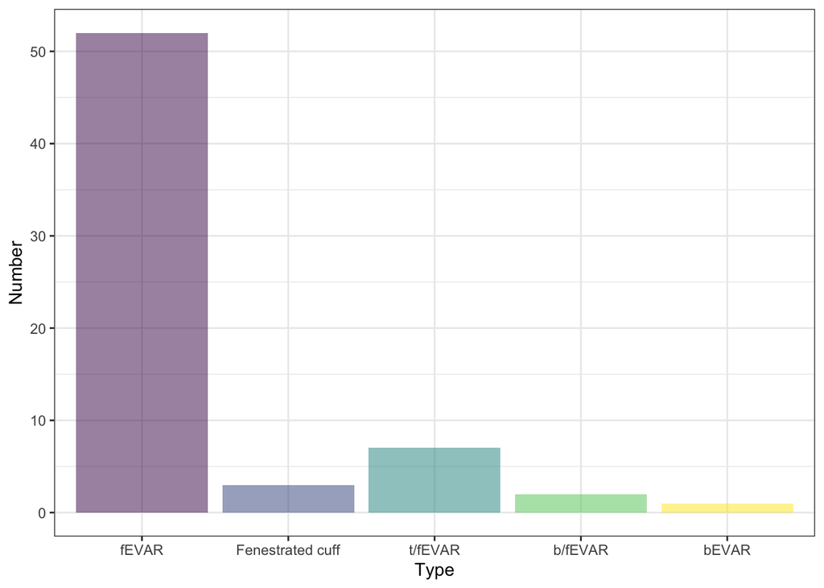

- t/fEVAR is a fEVAR with a separate thoracic stent-graft component.
- b/fEVAR is a combined branch and fenestrated custom device.
- bEVAR is an off-the-shelf branched device.

### 5.1.3 Planned fenestration numbers

- The number of planned fenestrations and/or branchse are shown in the following chart:

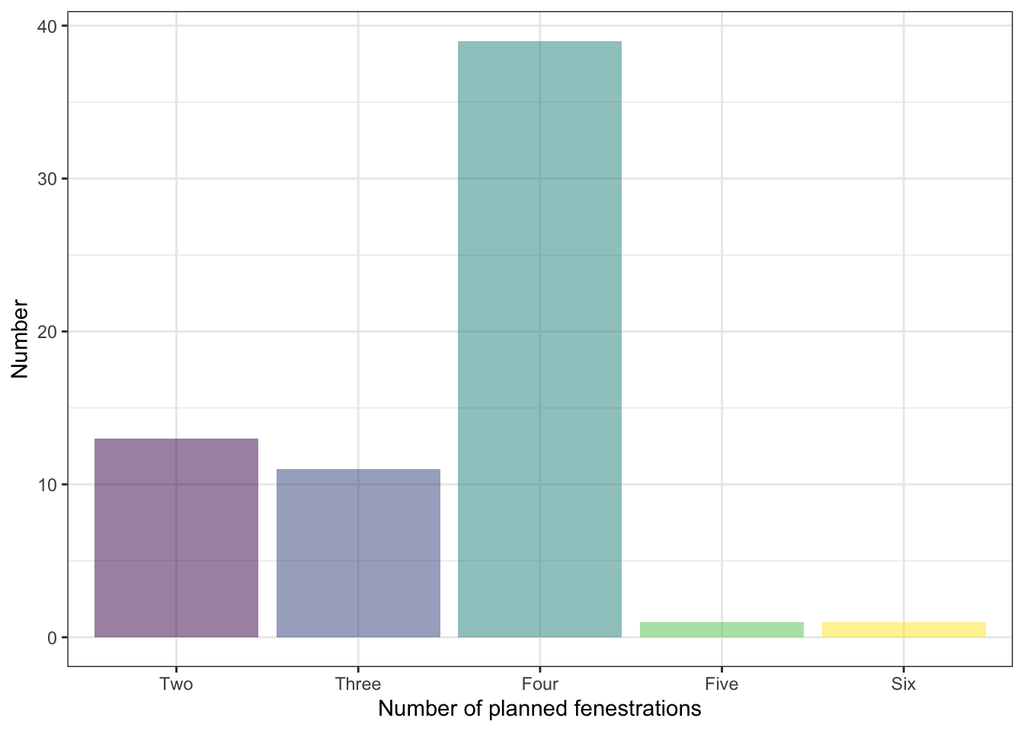

### 5.1.4 Radiation

- Radiation dose is presented below as dose area product, with three histograms each with colouring based on a separate factor, namely the device used, the type of fEVAR and the number of planned fenestrations:

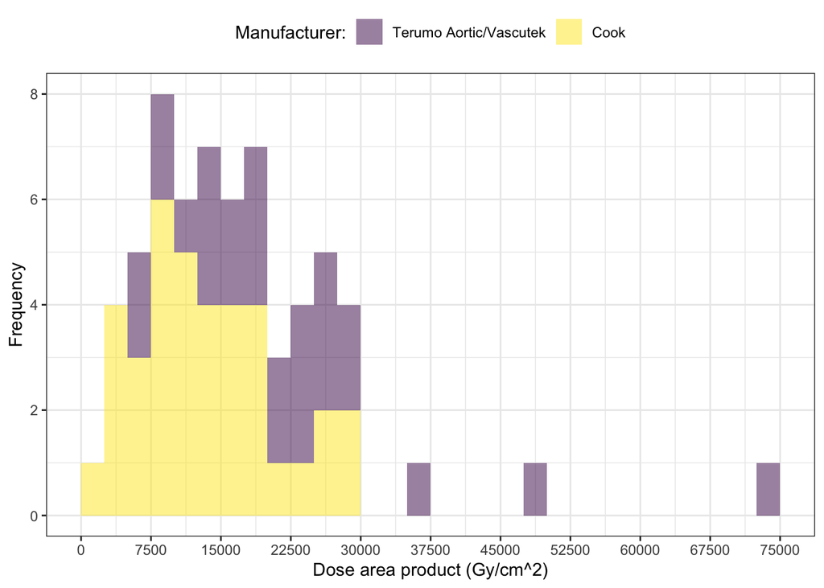

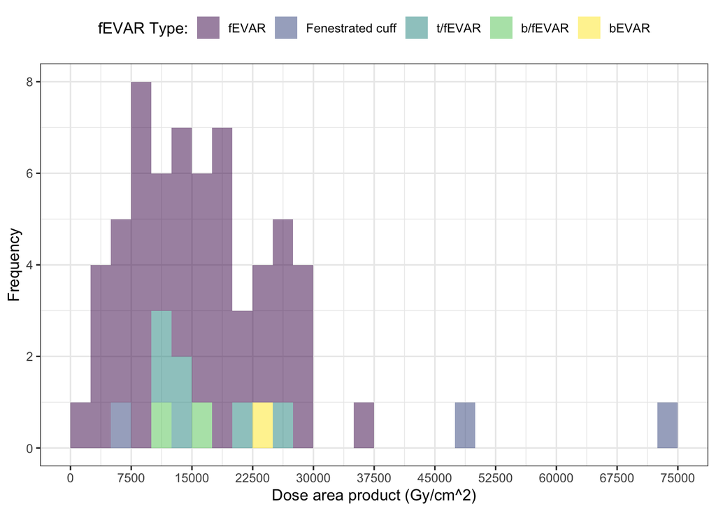

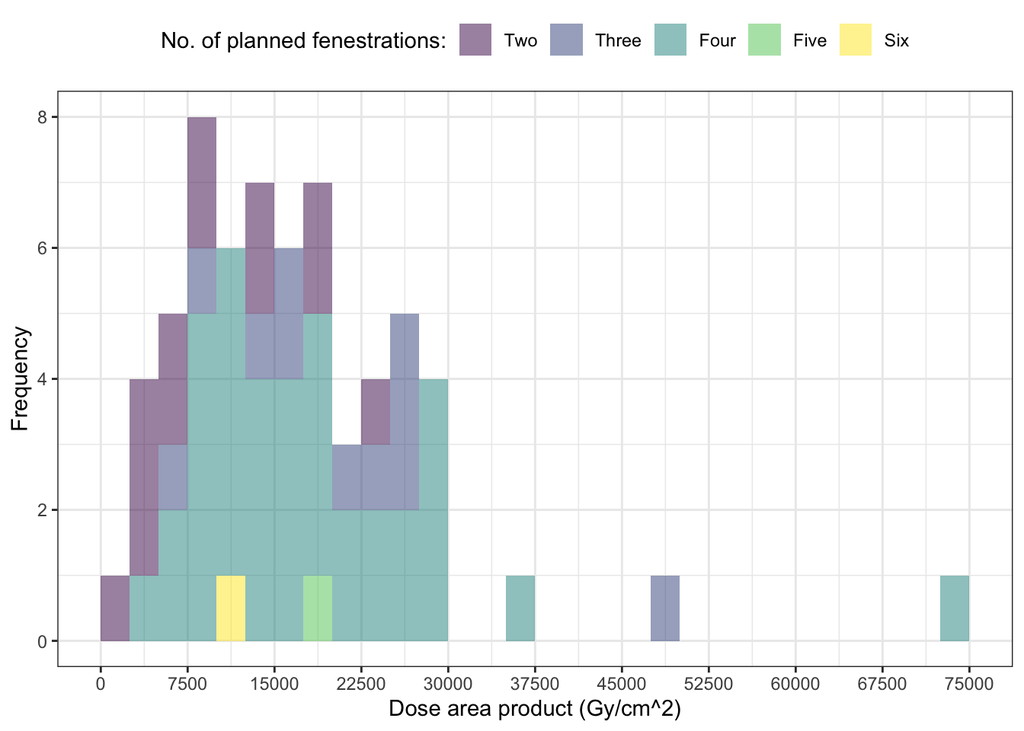

- From the above histograms, three fenestrated cuff procedures have resulted in two dose outliers.
- They are therefore excluded from the summary statistics below.
- Firstly, DAP distribution but this can be tested by Shapiro Wilk normality test with the null hypothesis that the DAP data are normally distributed. *p* = 0.18 (ie. they are normally distributed).
- Summary DAP statistics are shown below:

| Characteristic | Value (Gy/cm^2) |
| --- | --- |
| Minimum DAP | 2461 |
| Maximum DAP | 35892 |
| Mean DAP* | 16000 |
| Standard deviation* | 8000 |

- *Mean and standard deviation have been rounded to the nearest thousand.

### 5.1.5 Access

- Referring to the method of femoral access, the options are “cut-down”, which may or may not involve a conduit, “percutaneous”, which at this institution means two Proglides pre-inserted before the large sheath and “hybrid” in which one groin is accessed by each method.
- The numbers are shown on the following chart:

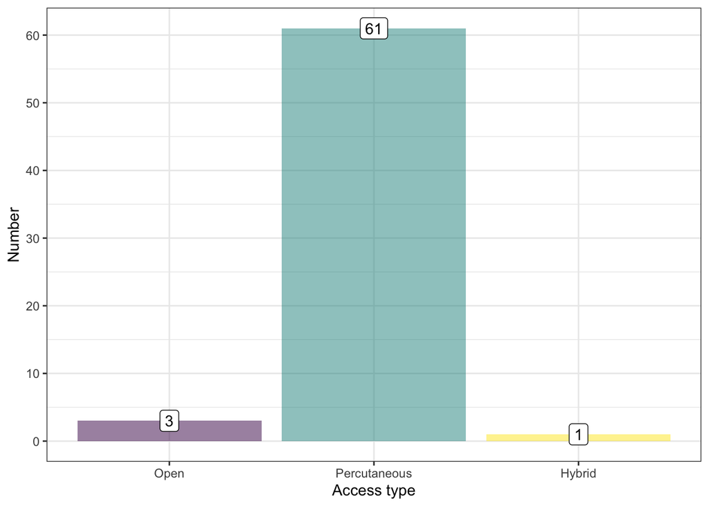

- ‘Hybrid’ means one femoral cut-down with percutaneous access on the other side.
- Unsuccessful percutaneous access is defined as any situation in which surgical haemostasis was required on a groin that was accessed percutaneously.
- The numbers are shown on the following chart:

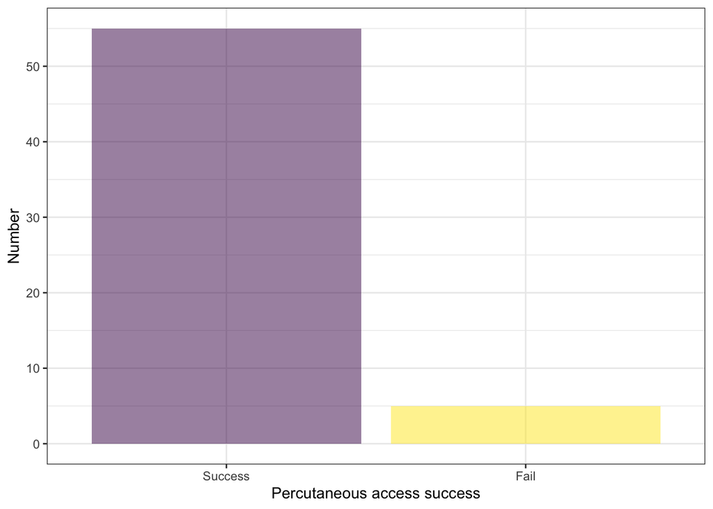

- Hybrid access cases are included in the above data.
- Use of upper limb access, whether planned or un-planned, and whether used for cannulation of a fenestration or any other reason, is shown on the following chart:

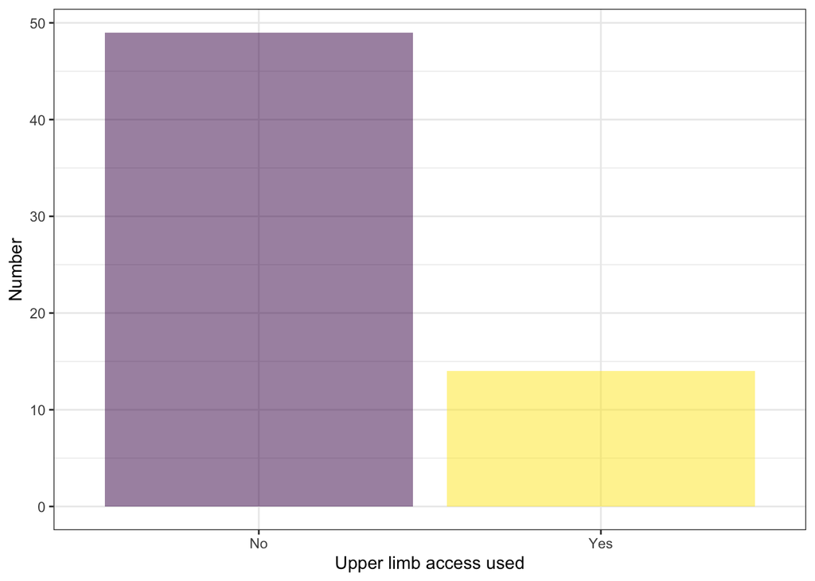

## 5.2 Patient

### 5.2.1 ASA

- Patient status has been collected as ASA only, and is shown below:

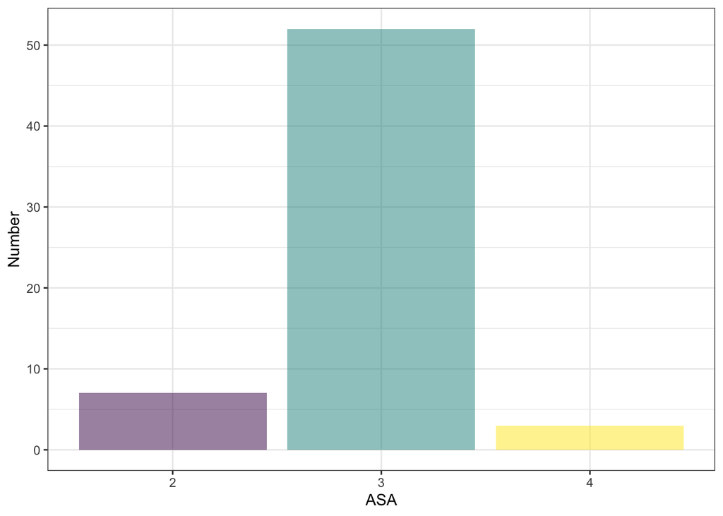

### 5.2.2 Anaesthetic

- Method of anaesthesia used for fEVAR is shown below:

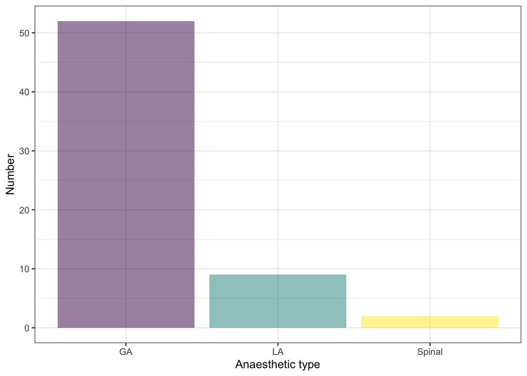

## 5.3 Hospital stay

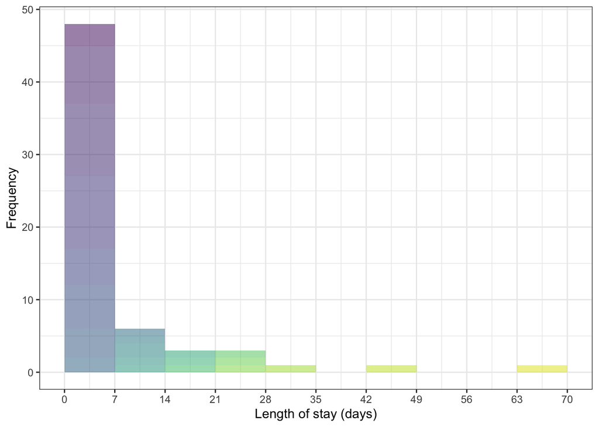

## 5.4 Survival

- Survival after fEVAR is shown below:

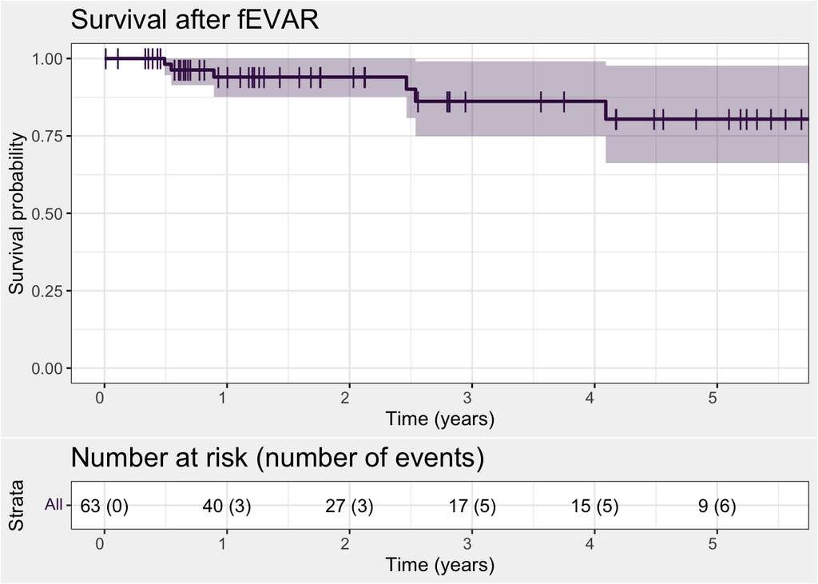

- Survival split by fEVAR type is shown below:

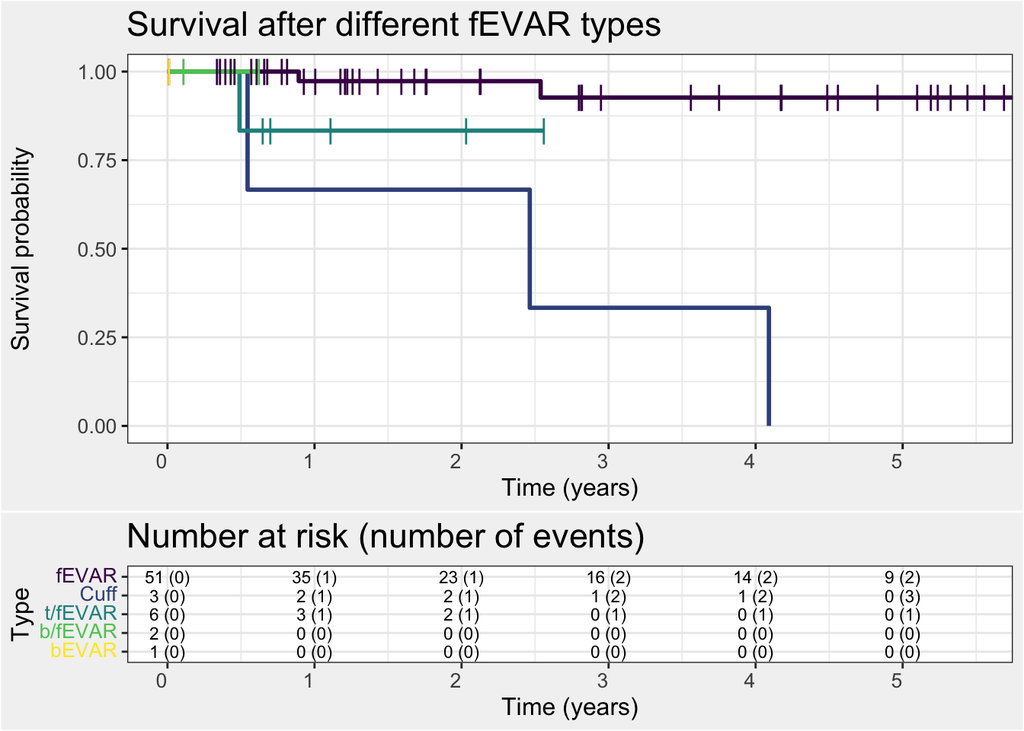